# Bayesian Statistics Workshop (2024)

Janna Wold Wennberg

2024-04-18

In order to run this notebook you should have the following packages installed: `plyr`, `tidyverse`, `ggplot2`, `viridis`, and `circular`.

## Example: Visual working memory

This example uses existing data from a visual working memory study (preprint, if you please: https://osf.io/preprints/psyarxiv/k9hrz) .

The goal is to test for: * Main effect of set size (how many items are in working memory) * Main effect of display condition (heterogeneous vs homogeneous) * Interaction between set size and display condition

First, let’s load and wrangle the data:

### Unrelated to Bayesian statistics, just getting data in the desired format

Just run this, don’t worry :)

```r
require("httr")
url <- 'https://osf.io/c68ap//?action=download'
filename <- 'osf_dataframe.csv'
GET(url, write_disk(filename, overwrite = TRUE))
```

```
## Response [https://files.osf.io/v1/resources/h456p/providers/osfstorage/6523422aef1e10035d26f1bb?action=download&direct&version=1]
##   Date: 2024-04-18 17:17
##   Status: 200
##   Content-Type: text/csv
##   Size: 3.14 MB
## <ON DISK>  /Users/jwennber/Dropbox/janna_bayes_workshop_2024/osf_dataframe.csv
```

```r
df.data_ex1 <- read.csv(filename, header=TRUE, na.strings="NA") %>%
  mutate(id = as.factor(id),
          setSize = factor(setSize, levels=c("1","2","4")),
          cond = factor(cond, levels = c("undef","hom","het"))
          )

df.circstats_ex1 <- df.data_ex1 %>%
  filter(setSize != "1") %>%
  group_by(id,probeFeat,cond,setSize) %>%
  summarise(circMean = mean.circular(circular(respErrorRad)),
            circSD = sd.circular(circular(respErrorRad)),
            .groups = "keep") %>%
  ungroup() %>%
  mutate(id = as.factor(id))

n = n_distinct(df.circstats_ex1$id)
df.plt <- df.circstats_ex1 %>%
  group_by(probeFeat, cond, setSize) %>%
  summarise(mean_sd = mean(circSD),
            sd_sd = sd(circSD),
            se_sd = sd_sd/sqrt(n),
            .groups = "keep") %>%
  ungroup()
```

### Looking at the data

Here, I am generating a plot of working memory precision (higher = worse) as a function of set size (x-axis) and display condition. We’re also doing these analyses separately for each experimental condition.

[figure not shown]

### Bayesian inference

Okay, so our goal is to assess whether there is a main effect of set size, a main effect of display condition, and an interaction! In order to do this, we will do a Bayesian repeated-measures ANOVA.

```r
anova_ex1 <- df.circstats_ex1 %>%
  filter(probeFeat == "color") %>%
  anovaBF(formula = circSD ~ cond + setSize + cond*setSize + id,
          whichRandom = "id")
print(anova_ex1)
```

```
## Bayes factor analysis
## --------------
## [1] cond + id                          : 25208.38     ±0.9%
## [2] setSize + id                       : 1.082919e+22 ±0.76%
## [3] cond + setSize + id                : 6.969686e+34 ±3.74%
## [4] cond + setSize + cond:setSize + id : 3.363694e+34 ±2.19%
##
## Against denominator:
##   circSD ~ id
## ---
## Bayes factor type: BFlinearModel, JZS
```

*BUT YOU ARE NOT DONE AFTER THIS STEP!!* The above step generated Bayes Factors for a number of possible models but compared them to *an intercept-only model* where Participant ID is the only source of variance in the data. The enormous Bayes Factors in the output mean that any of these models are more likely than the intercept-only model. But that doesn’t answer our question! So we want to compute the Bayes Factor ratio between nested models in order to assess main effects and interactions!

```r
# To see if there is a set size and display condition interaction,
# we will compare our full model [4] with a model that contains
# set size and display condition as fixed effects but no interaction

anova_ex1[4]/anova_ex1[3] # not strong evidence either way, but weak evidence against interaction
```

```
## Bayes factor analysis
## --------------
## [1] cond + setSize + cond:setSize + id : 0.4826178 ±4.34%
##
## Against denominator:
##   circSD ~ cond + setSize + id
## ---
## Bayes factor type: BFlinearModel, JZS
```

```r
anova_ex1[3]/anova_ex1[1] # VERY strong evidence for main effect of set size
```

```
## Bayes factor analysis
## --------------
## [1] cond + setSize + id : 2.764829e+30 ±3.85%
##
## Against denominator:
##   circSD ~ cond + id
## ---
## Bayes factor type: BFlinearModel, JZS
```

```r
anova_ex1[3]/anova_ex1[2] # VERY strong evidence for main effect of display condition
```

```
## Bayes factor analysis
## --------------
## [1] cond + setSize + id : 6.436017e+12 ±3.82%
##
## Against denominator:
##   circSD ~ setSize + id
## ---
## Bayes factor type: BFlinearModel, JZS
```

```r
df.circstats_ex1_setsize4 <- df.circstats_ex1 %>%
  filter(setSize == "4")

ttestBF(df.circstats_ex1_setsize4$circSD[df.circstats_ex1_setsize4$cond == "het"],
        df.circstats_ex1_setsize4$circSD[df.circstats_ex1_setsize4$cond == "hom"],
        paired = TRUE)
```

```
## Bayes factor analysis
## --------------
## [1] Alt., r=0.707 : 732162562 ±0%
##
## Against denominator:
##   Null, mu = 0
## ---
## Bayes factor type: BFoneSample, JZS
```

```r
samples = ttestBF(df.circstats_ex1_setsize4$circSD[df.circstats_ex1_setsize4$cond == "het"],
          df.circstats_ex1_setsize4$circSD[df.circstats_ex1_setsize4$cond == "hom"],
          paired = TRUE, posterior = TRUE, iterations = 1000)
quantile(samples[,"mu"], probs=c(0.025,0.975), na.rm = FALSE)
```

```
##        2.5%       97.5%
## -0.11456783 -0.06679246
```

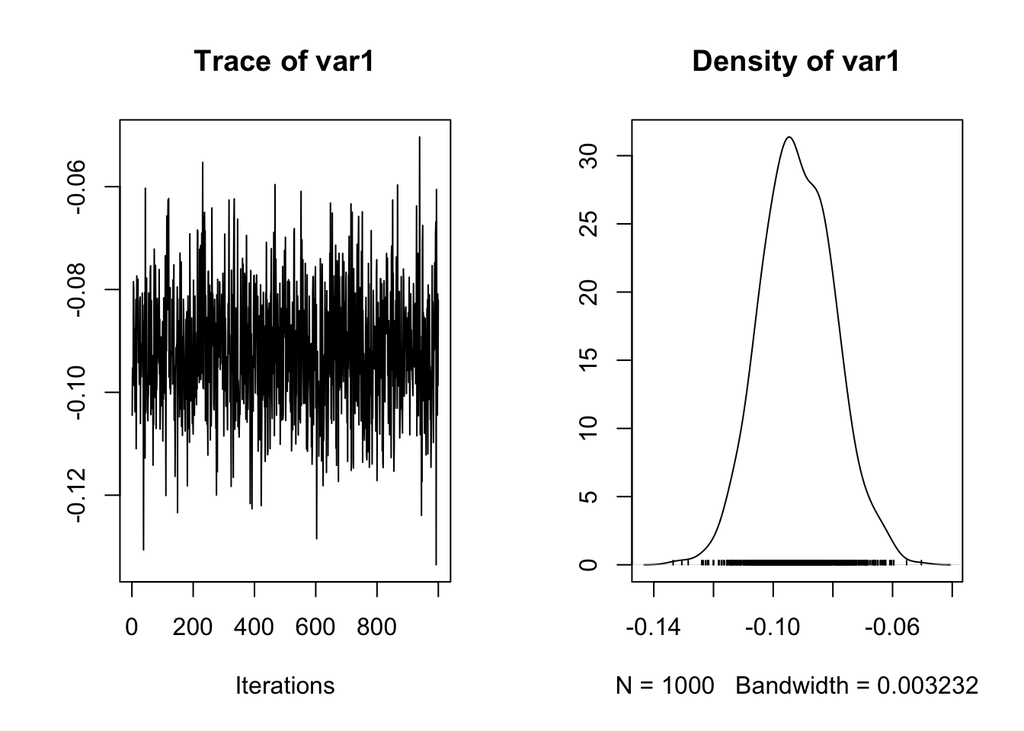

```r
plot(samples[,"mu"])
```

```r
mean(samples[,"mu"] < 0)
```

```
## [1] 1
```

```r
mean(samples[,"mu"] < -0.06)
```

```
## [1] 0.996
```